# Lógica y Pensamiento Científico

Correlación y causalidad

Bogdan G. Popescu

bgpopescu@tec.mx

Tecnologico de Monterrey

# Bienvenidos

## Objetivos de aprendizaje

### Panorama

1. Distinguir la correlación de la causalidad.
2. Deducir qué predice cada explicación rival — y nombrar la comparación que permitiría distinguirlas.
3. Leer un estudio científico con ojo crítico: tamaño de muestra, metodología y posibles sesgos.

## Ruta del día

### Hacia dónde vamos hoy

1. **El problema de Hume**: por qué el conocimiento causal nunca se observa directamente
2. **Correlación vs. causalidad**: los cuatro sospechosos de siempre detrás de cualquier patrón
3. **La Auditoría de Inferencias**: una herramienta para poner a prueba cada “por lo tanto”
4. **Leer un estudio con ojo crítico**: muestras, métodos, sesgos, p-hacking
5. **Los ejercicios**

## Repaso: las herramientas hasta ahora

| Etapa | Herramienta |
| --- | --- |
| Conocimiento | Tipos de conocimiento; qué hace que un conocimiento sea *científico* |
| Argumentos | Premisas, conclusiones, estructura del argumento |
| Lógica | Validez, solidez, deducción vs. inducción |
| Modos de falla | Falacias, información errónea, persuasión |

Hoy pasamos de los *argumentos* a la *evidencia*: ¿qué ocurre cuando las premisas son afirmaciones empíricas sobre el mundo?

# Parte 1: el problema de Hume

Por qué la causalidad siempre es una inferencia

## ¿Qué observamos en realidad?

Suelten un gis. ¿Qué *ven*?

- Ven que la mano suelta el gis.
- Ven que el gis cae.
- **No** ven que el soltarlo *cause* la caída.

Hume (1748): nunca observamos la causalidad misma — solo la **conjunción constante**: ocurre A, luego ocurre B, una y otra vez.

## El reto de Hume

> “Todos los razonamientos sobre cuestiones de hecho parecen fundarse en la relación de causa y efecto… las causas y los efectos no se descubren por la razón, sino por la experiencia.”

> — Hume, *Investigación*, Sección IV

Tres afirmaciones que nadie ha *visto* ocurrir:

- *“Fumar causa cáncer”* — nadie vio transformarse una célula.
- *“La austeridad causó la recesión”* — nadie vio al presupuesto encoger la economía.
- *“Las redes sociales causan polarización”* — nadie vio endurecerse una opinión.

Cada vez vimos un **patrón**. La palabra *causa* es una **inferencia** — algo que nosotros añadimos.

**Consecuencia:** las afirmaciones causales siempre pueden estar equivocadas. El patrón es real; la historia que contamos sobre él puede no serlo.

# Parte 2: Correlación vs. Causalidad

Los cuatro sospechosos de siempre detrás de cada patrón

## ¿Qué es una correlación?

Dos variables están **correlacionadas** cuando se mueven juntas:

- Suben las ventas de helado; suben las muertes por ahogamiento.
- Los países que consumen más chocolate ganan más premios Nobel.
- Los estudiantes que toman apuntes a mano sacan mejores calificaciones.

Una correlación es un **hecho sobre los datos**.

## Toda correlación tiene cuatro sospechosos

X está correlacionada con Y. ¿Por qué? Reúnan a los cuatro de siempre antes de buscar más lejos:

1. **X causa Y** — la historia a la que solemos brincar
2. **Y causa X** — causalidad inversa
3. **Z causa ambas** — una variable de confusión (variable oculta)
4. **El azar** — coincidencia, sobre todo con muestras pequeñas

## Sospechoso 2: causalidad inversa

- “Los empleados más felices son más productivos”. ¿O será que a los empleados productivos los ascienden, les pagan mejor, los elogian — y por eso *se vuelven* más felices?
- “La presencia policial está correlacionada con el delito”. ¿La policía causa el delito — o la mandan *a donde ya hay delito*?

**La prueba:** apunten la flecha en ambas direcciones y digan cada historia en voz alta.

- **X → Y** — ¿esa historia tiene sentido?
- **Y → X** — ¿y *esa otra* también?

**Si las dos historias funcionan, la correlación no puede decirles cuál es la verdadera.**

## Sospechoso 3: variables de confusión

Las ventas de helado y los ahogamientos suben juntos. ¿El helado causa ahogamientos?

El **verano** causa ambos: el calor impulsa la venta de helado *y* que la gente se meta a nadar.

Variables de confusión clásicas en ciencias sociales:

- **Riqueza**: correlaciona con salud, educación, confianza, instituciones…
- **Edad**: correlaciona con ingreso, posturas políticas, hábitos de consumo de medios…
- **Educación**: correlaciona con casi todo

**Prueba:** pregúntense “¿qué tercer factor podría producir ambas cosas?”

## Sospechoso 4: el azar

Con suficientes variables, las correlaciones absurdas están garantizadas:

- El consumo de queso en EE. UU. correlaciona con las muertes por enredarse con las sábanas.
- Las películas de Nicolas Cage por año correlacionan con los ahogamientos en albercas.

Si prueban 100 pares de variables, unos 5 se verán “estadísticamente significativos” por pura suerte.

Esto no es una broma sobre malos investigadores — es una propiedad matemática de buscar patrones. Recuérdenlo cuando lleguemos al *p-hacking*.

## La falacia ecológica

Un patrón en los **grupos** no tiene por qué cumplirse en los **individuos** que los forman — incluso puede correr al revés. Esto tiene nombre, y ocurrió de verdad:

- En los estados de EE. UU. en 1930: más residentes nacidos en el extranjero, *mayores* tasas de alfabetización en inglés.
- Pero los individuos nacidos en el extranjero estaban *menos* alfabetizados — se asentaban en estados de alta alfabetización *(Robinson 1950)*.
- Los **estados** más ricos se inclinan por un partido; los **votantes** más ricos, por el otro.
- **Prueba**: hagan coincidir el nivel de los datos (estado, escuela, país) con el nivel de la afirmación.

## Ver la inversión

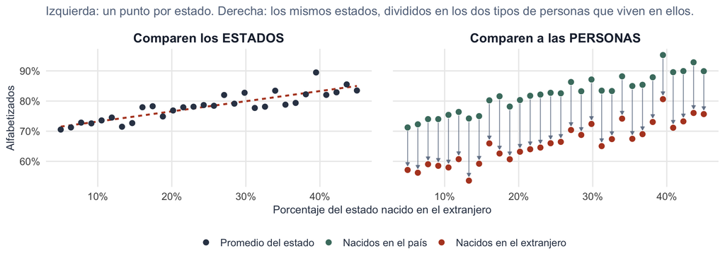

**Mismos estados, mismas personas, respuestas opuestas.** La línea punteada sube; todas las flechas apuntan hacia abajo. Ninguna de las dos imágenes está mal — responden preguntas distintas.

# Parte 3: la Auditoría de Inferencias

Una herramienta para poner a prueba cada “por lo tanto”

## El problema con “por lo tanto”

Los argumentos sobre evidencia esconden su paso más débil detrás de palabras inferenciales:

*por lo tanto — así — esto muestra — esto prueba — esto descarta — esto es incompatible con — esto confirma*

Estas palabras *afirman* que la evidencia sostiene la conclusión. No lo *demuestran*.

**La Auditoría de Inferencias:** cada vez que se topen con una de estas palabras, deténganse y pongan a prueba la lógica. Seis preguntas, una regla.

## El error de fondo que detecta

La mayoría de los malos argumentos empíricos comparten una estructura:

1. Quien escribe tiene una hipótesis favorita, H.
2. La evidencia es *compatible con* H.
3. Concluye que H es verdadera — **sin revisar si la evidencia también es compatible con la hipótesis rival.**

**La regla:** no pregunten solo si la evidencia embona con la historia del autor. Pregunten si también embona con la historia que el autor intenta rechazar.

## Las seis preguntas de la auditoría

1. **¿Cuál es la conclusión?** ¿Qué intenta probar, rechazar o explicar quien escribe?
2. **¿Cuáles son las premisas?** ¿Qué hechos o supuestos sirven de evidencia?
3. **¿Qué predeciría cada hipótesis?** Anoten qué nos llevaría a esperar la hipótesis principal *y* la rival — *antes* de juzgar.
4. **¿La evidencia coincide con la hipótesis que se rechaza?** Si sí, el argumento no ha refutado nada.
5. **¿La evidencia discrimina?** ¿O el mismo patrón aparecería bajo varias explicaciones?
6. **¿El patrón podría surgir de forma mecánica?** Efectos techo, regresión a la media, selección, cambio de composición, tendencias generales en el tiempo.

## Ejemplo resuelto: convergencia regional

Un pasaje de un informe de política pública realista:

> “Algunos culpan al federalismo por la lenta convergencia económica de las regiones pobres. Pero eso no puede ser: la convergencia fue *más rápida* bajo el sistema centralizado anterior y *se desaceleró* tras la descentralización. **Por lo tanto**, el federalismo no explica la lenta convergencia.”

Suena riguroso. Apliquen la auditoría.

## Ejemplo resuelto: aplicando la auditoría

1. **Conclusión:** el federalismo no explica la lenta convergencia.
2. **Premisas:** la convergencia fue rápida con la centralización y lenta tras la descentralización.
3. **¿Qué predeciría la rival?** Si el federalismo *frenara* la convergencia, esperaríamos… convergencia rápida bajo la centralización y más lenta tras la descentralización.
4. **¿La evidencia coincide con la hipótesis que se rechaza?** Sí — *exactamente*.

La evidencia que el autor usa para *refutar* la hipótesis del federalismo es justo lo que esa hipótesis *predice*. El “por lo tanto” está vacío.

## Ejemplo resuelto: la lección

- El autor nunca preguntó qué predeciría la hipótesis rival.
- La evidencia era compatible con **ambas** historias — así que no discrimina entre **ninguna**.
- El autor necesitaba una mejor comparación (¿regiones con más vs. menos autonomía?) o una afirmación más modesta.

**Nombren el error:** *no deducir la predicción de la hipótesis rival.*

Esto es **sesgo de confirmación**, presentado como análisis de datos.

## Pregunta 6: explicaciones mecánicas

Antes de aceptar una historia de fondo, revisen si el patrón podría surgir solo de la aritmética:

| Patrón | Posible causa mecánica |
| --- | --- |
| “La mejora se desaceleró tras la reforma” | Efecto techo, rendimientos decrecientes |
| “Los peores fueron los que más mejoraron” | Regresión a la media |
| “A los participantes del programa les fue mejor” | Selección: ¿quién se inscribe? |
| “El promedio bajó al crecer la matrícula” | Cambio de composición |
| “X subió en la década, y Y también” | Ambas siguen una tendencia general |

Ninguna de estas exige que la historia del autor sea cierta — ni falsa. Exigen que el autor las *descarte*.

## El Chequeo Lógico Rápido

### La versión para memorizar

Por cada **“por lo tanto”** de un argumento, pregunten:

1. ¿Cuál es la **afirmación**?
2. ¿Cuál es la **evidencia**?
3. ¿Qué predeciría **cada explicación en competencia**?
4. ¿La evidencia embona con la explicación del autor, con la rival, **con ambas o con ninguna**?
5. ¿La conclusión de veras **se sigue**?

**Prueba final:** si la hipótesis rival predice el mismo patrón que observamos, la evidencia no puede usarse para rechazar esa rival.

# Parte 4: leer un estudio con ojo crítico

Muestra, método, sesgo

## Un estudio es un argumento

Un estudio científico no es un hecho — es un **argumento**: premisas (datos, métodos) que sostienen una conclusión (hallazgos).

Así que todo lo que el curso ha enseñado sobre argumentos — más la Auditoría de Inferencias — aplica. Más tres preguntas propias de los estudios:

1. **¿A quién se estudió?** (muestra)
2. **¿Cómo se midió el efecto?** (metodología)
3. **¿A quién beneficia el resultado?** (sesgos e incentivos)

## Pregunta 1: la muestra

- **Tamaño**: una encuesta a 40 estudiantes dice poco; “n = 12” es señal de alerta.
- **Selección**: una encuesta en línea sobre regulación de internet muestrea… a gente que está en internet.
- **Muestras WEIRD**: buena parte de la psicología estudia poblaciones occidentales, educadas, industrializadas, ricas y democráticas — sobre todo estudiantes de licenciatura — y generaliza a toda la humanidad.

**Pregunten:** quién está *en* la muestra, quién *falta*, y si la conclusión se extiende calladamente más allá de la gente que de verdad se estudió.

## Pregunta 2: la metodología

- **¿Experimento u observación?** La asignación aleatoria rompe la confusión; la observación no.
- **¿Qué se mide en realidad?** La “felicidad” medida como respuesta de encuesta del 1 al 10 no es lo mismo que la felicidad.
- **¿Comparado con qué?** “El delito bajó tras la política” — ¿comparado con ciudades sin esa política? ¿Con la tendencia previa?

## Pregunta 3: sesgos e incentivos

- ¿Quién financió el estudio?
- ¿La carrera de quien investiga se beneficiaría más de un resultado que de otro?
- Las revistas prefieren hallazgos **positivos y sorprendentes** — los resultados ciertos pero aburridos son más difíciles de publicar que los emocionantes pero frágiles.

Sesgo no quiere decir fraude. Quiere decir que el *filtro* entre todos los estudios que se hacen y los que ustedes alcanzan a leer no es neutral.

## p-Hacking

Recuerden: prueben 100 comparaciones y unas 5 se verán significativas por azar.

Ahora imaginen a alguien que prueba muchos resultados, subgrupos y especificaciones de modelo — y reporta el que “funcionó”.

- Cada paso por separado puede parecer razonable.
- El resultado reportado es real *en los datos* — y no dice nada *sobre el mundo*.
- El artículo publicado les muestra 1 comparación, no las 99.

Esta es la explicación por azar de la Parte 2, a gran escala.

## Las comparaciones que nunca ven

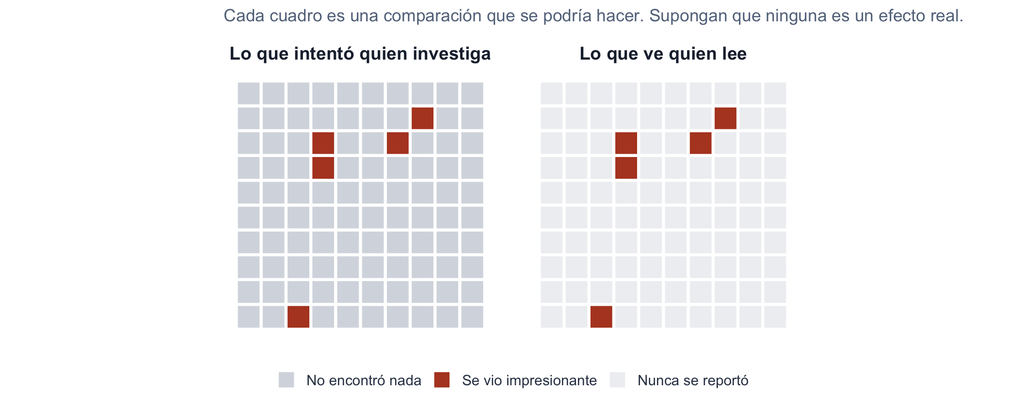

**Los cuadros rojos son idénticos en ambos paneles — y cada uno de ellos es suerte.** No pueden distinguir un cuadro con suerte de un hallazgo real con solo mirarlo. Solo pueden preguntar cuántos cuadros había.

# Los ejercicios

## Los ejercicios: auditen cuatro afirmaciones

Para cada afirmación: identifiquen el patrón, nombren a los sospechosos rivales (causalidad inversa, variable de confusión, azar, mecánico) — y luego respondan la pregunta que lo decide:

**¿Qué comparación querrían ver?**

1. “Los estudiantes que van a asesorías sacan mejores calificaciones. Por lo tanto, ir a asesorías mejora las calificaciones.”
2. “Las escuelas peor evaluadas en 2020 fueron las que más mejoraron para 2024. Por lo tanto, el programa de recuperación funciona.”
3. “Los países que adoptaron austeridad crecieron menos. Por lo tanto, la austeridad causa bajo crecimiento.”
4. “El delito bajó 30% después de que entró la nueva alcaldesa. Esto prueba que sus políticas funcionan.”

## Los ejercicios — respuestas

**1.** *“Los estudiantes que van a asesorías sacan mejores calificaciones — por lo tanto las asesorías mejoran las calificaciones.”*

- Sospechoso principal: **variable de confusión**. La disciplina que te lleva a las asesorías también te lleva a hacer las lecturas.
- **La comparación:** inviten al azar a la mitad del grupo. Comparen *invitados* con *no invitados* — nunca a quienes asisten con quienes no.

**2.** *“Las escuelas peor evaluadas en 2020 fueron las que más mejoraron para 2024 — por lo tanto el programa de recuperación funciona.”*

- Sospechoso principal: **mecánico — regresión a la media**. Quedar en último lugar requiere debilidad real *más* mala suerte, y la suerte no se repite.
- **La comparación:** escuelas igual de mal evaluadas que no recibieron el programa. ¿Repuntaron lo mismo?

**3.** *“Los países que adoptaron austeridad crecieron menos — por lo tanto la austeridad causa bajo crecimiento.”*

- Sospechoso principal: **causalidad inversa**. Los países adoptan austeridad *porque* el crecimiento y la recaudación ya se desplomaron.
- **La comparación:** países en los mismos apuros fiscales que *no* adoptaron austeridad.

**4.** *“El delito bajó 30% después de que entró la nueva alcaldesa — esto prueba que sus políticas funcionan.”*

- Sospechoso principal: **mecánico — una tendencia general en el tiempo**, más regresión a la media: la eligieron justo después de un pico.
- **La comparación:** los mismos cuatro años en ciudades comparables que no cambiaron de alcalde.

**Todas las respuestas tienen la misma forma: nombren a la rival y luego nombren la comparación que las distinguiría.**

## ¿Qué nos daría más confianza?

Un solo estudio que sobrevive la auditoría sigue siendo *un solo estudio*.

- **Replicación** — el mismo resultado, hallado de nuevo, por alguien sin nada en juego.
- **Métodos distintos** — que encuesta, experimento y datos administrativos coincidan es difícil de fingir; cada uno tiene debilidades distintas.
- **Muestras distintas** — otro país, otra década, otra población.
- **Convergencia** — líneas de evidencia independientes que apuntan en la misma dirección.

Fíjense en lo que tienen en común: cada una es una **comparación**. Cada una pregunta si el patrón sobrevive un cambio que un resultado espurio no sobreviviría.

## Cierre

- La causalidad nunca se observa — solo se infiere (Hume).
- Toda correlación tiene cuatro sospechosos de siempre — y son el inicio de la lista, no toda la lista; la carga es *discriminar*, no *embonar*.
- La Auditoría de Inferencias: deduzcan qué predice la **rival** antes de aceptar cualquier “por lo tanto”.
- Un estudio es un argumento: revisen muestra, método e incentivos.
- Los estudios aislados son evidencia débil; la replicación y la convergencia son evidencia fuerte.

## Referencias

- Hume, D. (2007). *An enquiry concerning human understanding* (P. Millican, Ed.). Oxford University Press. (Obra original publicada en 1748; Sección IV.)
- Robinson, W. S. (1950). Ecological correlations and the behavior of individuals. *American Sociological Review, 15*(3), 351–357.